# Exercise Prediction - PML Project

Philip Mateescu

January 29, 2016

# Using Machine Learning to Predict Exercise Correctness

Using fitness device (*Jawbone Up*, *Nike FuelBand*, *Fitbit*) [data collected](http://groupware.les.inf.puc-rio.br/har) by a group of enthusiasts, we will attempt to construct a Machine Learning model that will predict “how (well)” an activity has been performed by the wearer.

The dataset has been obtained from the [Human Activity Recognition](http://groupware.les.inf.puc-rio.br/har) project.

## Dataset Cleanup and Exploratory Analysis

The training data has been obtained from https://d396qusza40orc.cloudfront.net/predmachlearn/pml-training.csv and the test data has been downloaded from https://d396qusza40orc.cloudfront.net/predmachlearn/pml-testing.csv

Both files have been places in a `data` subdirectory.

```r
set.seed(5318008)
training <- read.csv('data/pml-training.csv')
training$classe <- as.factor(training$classe)
testing <- read.csv('data/pml-testing.csv')
```

From the study’s [documentation](http://groupware.les.inf.puc-rio.br/public/papers/2013.Velloso.QAR-WLE.pdf), we learned that the authors have added eight feature that are calculate values of other variables: mean, variance, standard deviation, max, min, amplitude, kurtosis and skewness.  
We will eliminate these.

```r
calculatedColumns <- grepl('^(mean|var|stddev|max|min|skew|kurt|ampli|avg)', colnames(testing))
```

Upon initial inspection using `str(testing)` and `summary(testing)` we notice that there is no data (either N/A or empty) for some of the 160 variables in the dataset. These would *not* make for good predictor variables.

```r
isMissing <- function(x) { any(is.na(x) || x == "")}
missingValues <- sapply(testing, isMissing)
```

We will combine the two sets to create our predictor set and exclude them alongside some of the columns that don’t hold measurement data (e.g. *user_name* or timestamps)

```r
excluded <- c('X', 'user_name', 'new_window', 'num_window', 'cvtd_timestamp',
              'problem_id', 'raw_timestamp_part_1', 'raw_timestamp_part_2')
n <- names(testing)
n <- n[!missingValues | !calculatedColumns]
predictors <- n[!(n %in% excluded)]
predictors
```

```
##  [1] "roll_belt"            "pitch_belt"           "yaw_belt"
##  [4] "total_accel_belt"     "gyros_belt_x"         "gyros_belt_y"
##  [7] "gyros_belt_z"         "accel_belt_x"         "accel_belt_y"
## [10] "accel_belt_z"         "magnet_belt_x"        "magnet_belt_y"
## [13] "magnet_belt_z"        "roll_arm"             "pitch_arm"
## [16] "yaw_arm"              "total_accel_arm"      "gyros_arm_x"
## [19] "gyros_arm_y"          "gyros_arm_z"          "accel_arm_x"
## [22] "accel_arm_y"          "accel_arm_z"          "magnet_arm_x"
## [25] "magnet_arm_y"         "magnet_arm_z"         "roll_dumbbell"
## [28] "pitch_dumbbell"       "yaw_dumbbell"         "total_accel_dumbbell"
## [31] "gyros_dumbbell_x"     "gyros_dumbbell_y"     "gyros_dumbbell_z"
## [34] "accel_dumbbell_x"     "accel_dumbbell_y"     "accel_dumbbell_z"
## [37] "magnet_dumbbell_x"    "magnet_dumbbell_y"    "magnet_dumbbell_z"
## [40] "roll_forearm"         "pitch_forearm"        "yaw_forearm"
## [43] "total_accel_forearm"  "gyros_forearm_x"      "gyros_forearm_y"
## [46] "gyros_forearm_z"      "accel_forearm_x"      "accel_forearm_y"
## [49] "accel_forearm_z"      "magnet_forearm_x"     "magnet_forearm_y"
## [52] "magnet_forearm_z"
```

These predictors include both “features on the Euler angles (roll, pitch and yaw), as well as the raw accelerometer, gyroscope and magnetometer readings” <sup>[1]</sup>.

Let’s create three sets of predictors: one that contains only raw data, one that contains the angles, and one that contains both and see which one yields better results.

```r
pred.angles <- predictors[grepl('roll|pitch|yaw', predictors)]
pred.raw <- predictors[!grepl('roll|pitch|yaw', predictors)]
training <- training[,c('classe', predictors)]
# the formulas we'll use
formula.all <- 'classe ~ .'
formula.angles <- paste('classe', '~', paste(pred.angles, collapse ='+'))
formula.raw <- paste('classe', '~', paste(pred.raw, collapse ='+'))
```

As we already have a testing set, let’s split the training set into a training and a validation set. Since the testing set is very small, we’ll create a larger validation set.

```r
inTrain <- createDataPartition(training$classe, p = 0.6)
data.train <- training[inTrain[[1]], ]
data.validation <- training[-inTrain[[1]], ]
```

[figure not shown]

## Modeling

```r
# to allow for succcessive runs, we'll load the models if previously saved
if (file.exists('models.RData')) {
    load(file='models.RData')
} else {

# create a parallel cluster - thanks for Len Greski
# https://github.com/lgreski/datasciencectacontent/blob/master/markdown/pml-randomForestPerformance.md
cluster <- makeCluster(detectCores() - 1)
registerDoParallel(cluster)

control <- trainControl(method='cv', number=5, allowParallel = T)
model.all <- train(formula(formula.all), data=data.train, method='rf', trControl=control)
model.angles <- train(formula(formula.angles), data=data.train, method='rf', trControl=control)
model.raw <- train(formula(formula.raw), data=data.train, method='rf', trControl=control)

stopCluster(cluster)
# save models for reruns
save(model.all, model.angles, model.raw, file='models.RData')
}
```

## Accuracy of Models

Let’s compare the accuracy of each of the models by running predictions against the validation set:

```r
predict.all <- predict(model.all, data.validation)
predict.angles <- predict(model.angles, data.validation)
predict.raw <- predict(model.raw, data.validation)
cm.all <- confusionMatrix(data.validation$classe, predict.all)
cm.angles <- confusionMatrix(data.validation$classe, predict.angles)
cm.raw <- confusionMatrix(data.validation$classe, predict.raw)
```

Comparison of Accuracy and Out-Of-Sample Error for various predictors

|  | All Predictors (52) | Angle Predictors (12) | Raw Sensors (40) |
| --- | --- | --- | --- |
| Accuracy | 99.6813663 | 99.4392047 | 99.3244966 |
| Out-of-sample error | 0.3186337 | 0.5607953 | 0.6755034 |

Indeed, if we examine the variable importance, we notice that the angle predictors are prominently present within the top 20 most important variables:

```r
varImp(model.all)
```

```
## rf variable importance
##
##   only 20 most important variables shown (out of 52)
##
##                      Overall
## roll_belt             100.00
## pitch_forearm          63.51
## yaw_belt               57.58
## magnet_dumbbell_z      47.45
## pitch_belt             45.76
## magnet_dumbbell_y      42.04
## roll_forearm           40.87
## accel_dumbbell_y       20.90
## roll_dumbbell          20.78
## magnet_dumbbell_x      19.87
## accel_forearm_x        18.35
## magnet_belt_z          16.55
## accel_dumbbell_z       15.16
## accel_belt_z           14.88
## total_accel_dumbbell   13.20
## magnet_forearm_z       12.64
## magnet_belt_y          11.71
## gyros_belt_z           11.65
## yaw_arm                10.55
## magnet_belt_x          10.19
```

Correlation of predictors predictors:

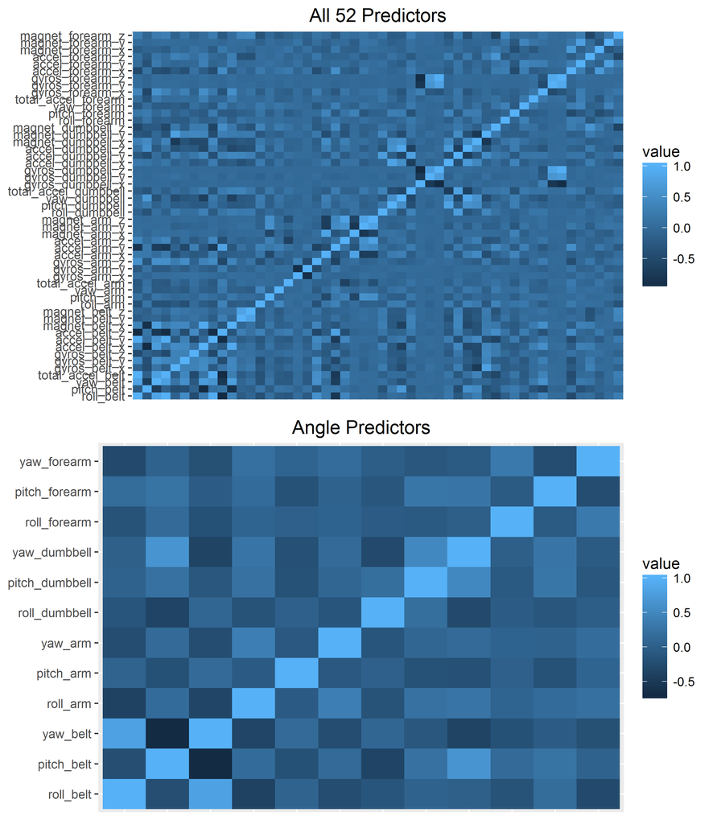

```r
c1.d <-melt(cor(data.train[,predictors]))
c2.d <-melt(cor(data.train[,pred.angles]))
c1 <- ggplot(data = c1.d, aes(x=Var1, y=Var2, fill=value)) +
    geom_tile() +
    theme(axis.text.x=element_blank(), axis.ticks.x=element_blank(), axis.title.x=element_blank(), axis.title.y=element_blank()) +
    ggtitle('All 52 Predictors')
c2 <- ggplot(data = c2.d, aes(x=Var1, y=Var2, fill=value)) +
    geom_tile() +
    theme(axis.text.x=element_blank(), axis.ticks.x=element_blank(), axis.title.x=element_blank(), axis.title.y=element_blank()) +
    ggtitle('Angle Predictors')
grid.arrange(c1, c2, nrow=2)
```

# Prediction on Test Data

```r
testing <- testing[,predictors]
pred.test.all <- predict(model.all, newdata = testing)
pred.test.angles <- predict(model.angles, newdata = testing)
pred.test.raw <- predict(model.raw, newdata = testing)
df.pred <- data.frame(all=pred.test.all, angles=pred.test.angles, sensors=pred.test.raw)
kable(df.pred)
```

| all | angles | sensors |
| --- | --- | --- |
| B | B | B |
| A | A | A |
| B | B | B |
| A | A | A |
| A | A | A |
| E | E | E |
| D | D | D |
| B | B | B |
| A | A | A |
| A | A | A |
| B | B | B |
| C | C | C |
| B | B | B |
| A | A | A |
| E | E | E |
| E | E | E |
| A | A | A |
| B | B | B |
| B | B | B |
| B | B | B |

As we can see, due to the high accuracy of the Random Forest algorithm all three models concur when applied to the test data.

# References and Citations

1. Velloso, E.; Bulling, A.; Gellersen, H.; Ugulino, W.; Fuks, H. Qualitative Activity Recognition of Weight Lifting Exercises. Proceedings of 4th International Conference in Cooperation with SIGCHI (Augmented Human ’13) . Stuttgart, Germany: ACM SIGCHI, 2013.